# STAT 420: Final Project

Spring 2019, S. Jain

## Contents

### Summary and Analysis Plan

We have to predict the severity of a disease based on the different genes of a person. Since there are no categorical values in our entire dataset, we will train different linear regression models to achieve our task; our models will include the full additive model and we will develop on it based on the different techniques learned over the course of the semester to find the `best` model that also satisfies all the assumptions of a linear regression model.

### Summary statistics and Data Visualization

There are a total of 21 variables in our data of 290 observations, out of which 20 are predictor variables.

The response variable is:

1. Disease Severity : Numerical Variable, No NULL values

The predictor variables are:

1. PCDH12 : Numerical Variable, No NULL values
2. DLG5: Numerical Variable, No NULL values
3. BC038559: Numerical Variable, No NULL values
4. SHISA5: Numerical Variable, No NULL values
5. AF161342: Numerical Variable, No NULL values
6. CARKD: Numerical Variable, No NULL values
7. F2R: Numerical Variable, No NULL values
8. PHKG1: Numerical Variable, No NULL values
9. CDCP1: Numerical Variable, No NULL values
10. PLEKHM1: Numerical Variable, No NULL values
11. SMC2: Numerical Variable, No NULL values
12. PSMB6: Numerical Variable, No NULL values
13. BX440400: Numerical Variable, No NULL values
14. A_24_P936373: Numerical Variable, No NULL values
15. PPAN: Numerical Variable, No NULL values
16. BC007917: Numerical Variable, No NULL values
17. C14orf143: Numerical Variable, No NULL values
18. LOC440104: Numerical Variable, No NULL values
19. THC2578957: Numerical Variable, No NULL values
20. ANKIB1: Numerical Variable, No NULL values

```r
summary(fullData)
```

```
##  Disease.Severity      PCDH12             DLG5           BC038559
##  Min.   : 0.6051   Min.   : 0.1984   Min.   :0.1612   Min.   :0.0000
##  1st Qu.: 1.7685   1st Qu.: 0.6907   1st Qu.:0.6971   1st Qu.:0.7266
##  Median : 2.1938   Median : 0.9356   Median :0.9324   Median :0.9753
##  Mean   : 2.8468   Mean   : 1.1141   Mean   :1.1149   Mean   :1.0668
##  3rd Qu.: 3.0518   3rd Qu.: 1.3315   3rd Qu.:1.3861   3rd Qu.:1.3200
##  Max.   :14.6548   Max.   :19.3246   Max.   :3.9557   Max.   :2.8893
##      SHISA5           AF161342          CARKD              F2R
##  Min.   :0.08121   Min.   :0.0000   Min.   : 0.2274   Min.   :0.08702
##  1st Qu.:0.80622   1st Qu.:0.7244   1st Qu.: 0.7345   1st Qu.:0.76860
##  Median :1.03409   Median :0.9646   Median : 0.9793   Median :1.00987
##  Mean   :1.12206   Mean   :1.2000   Mean   : 1.2472   Mean   :1.06476
##  3rd Qu.:1.39922   3rd Qu.:1.5557   3rd Qu.: 1.4130   3rd Qu.:1.31690
##  Max.   :3.16685   Max.   :4.4292   Max.   :11.2495   Max.   :2.40623
##      PHKG1            CDCP1           PLEKHM1              SMC2
##  Min.   :0.1896   Min.   :0.2157   Min.   :0.007247   Min.   : 0.08099
##  1st Qu.:0.7468   1st Qu.:0.8147   1st Qu.:0.625306   1st Qu.: 0.74681
##  Median :1.0614   Median :1.1547   Median :0.877979   Median : 1.12826
##  Mean   :1.1415   Mean   :1.3204   Mean   :1.000734   Mean   : 1.71930
##  3rd Qu.:1.4221   3rd Qu.:1.6786   3rd Qu.:1.312832   3rd Qu.: 1.77888
##  Max.   :3.9219   Max.   :4.9052   Max.   :2.617192   Max.   :20.22553
##      PSMB6           BX440400       A_24_P936373          PPAN
##  Min.   :0.1965   Min.   :0.1223   Min.   :0.05797   Min.   :0.1211
##  1st Qu.:0.7067   1st Qu.:0.8247   1st Qu.:0.75189   1st Qu.:0.8145
##  Median :0.9502   Median :1.0644   Median :0.94864   Median :1.0194
##  Mean   :1.0260   Mean   :1.1607   Mean   :1.09295   Mean   :1.1400
##  3rd Qu.:1.3112   3rd Qu.:1.4648   3rd Qu.:1.31270   3rd Qu.:1.3486
##  Max.   :2.9771   Max.   :3.1026   Max.   :4.78140   Max.   :3.0853
##     BC007917        C14orf143        LOC440104        THC2578957
##  Min.   :0.3353   Min.   :0.1992   Min.   :0.1258   Min.   :0.2324
##  1st Qu.:0.7600   1st Qu.:0.7259   1st Qu.:0.6718   1st Qu.:0.8174
##  Median :0.9970   Median :1.0319   Median :0.9608   Median :1.0249
##  Mean   :1.0925   Mean   :1.2932   Mean   :1.0608   Mean   :1.1337
##  3rd Qu.:1.3374   3rd Qu.:1.5615   3rd Qu.:1.3230   3rd Qu.:1.3492
##  Max.   :2.9338   Max.   :8.1067   Max.   :3.4603   Max.   :3.4320
##      ANKIB1
##  Min.   :0.07901
##  1st Qu.:0.76117
##  Median :0.98928
##  Mean   :1.05508
##  3rd Qu.:1.25422
##  Max.   :3.22517
```

Scatterplot matrix:

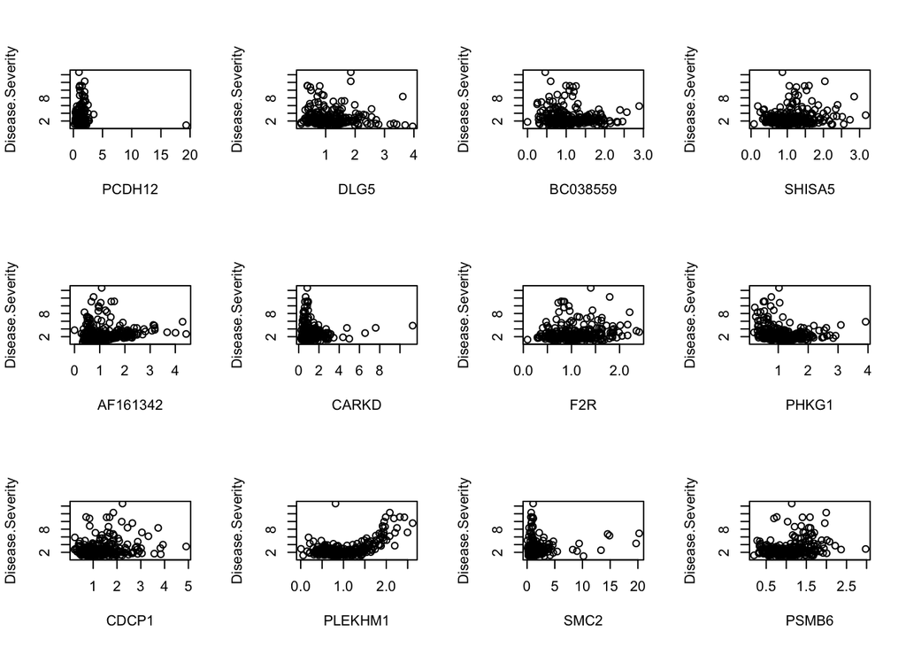

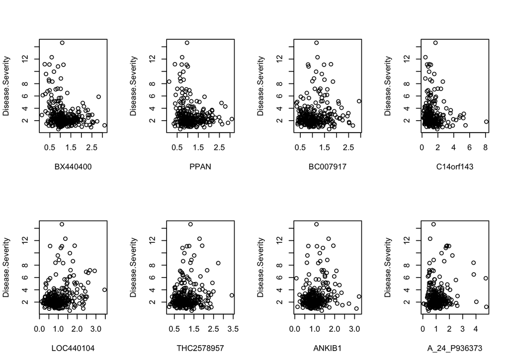

The scatterplots above show us how each predictor variable maps out with the Disease.Severity response variable. This is useful in gauging which variables might be of use to us, and shows individual trends in their relationships.

The correlation between all the variables amongst themselves is mapped in the correlation plot below.

Correlation Plot:

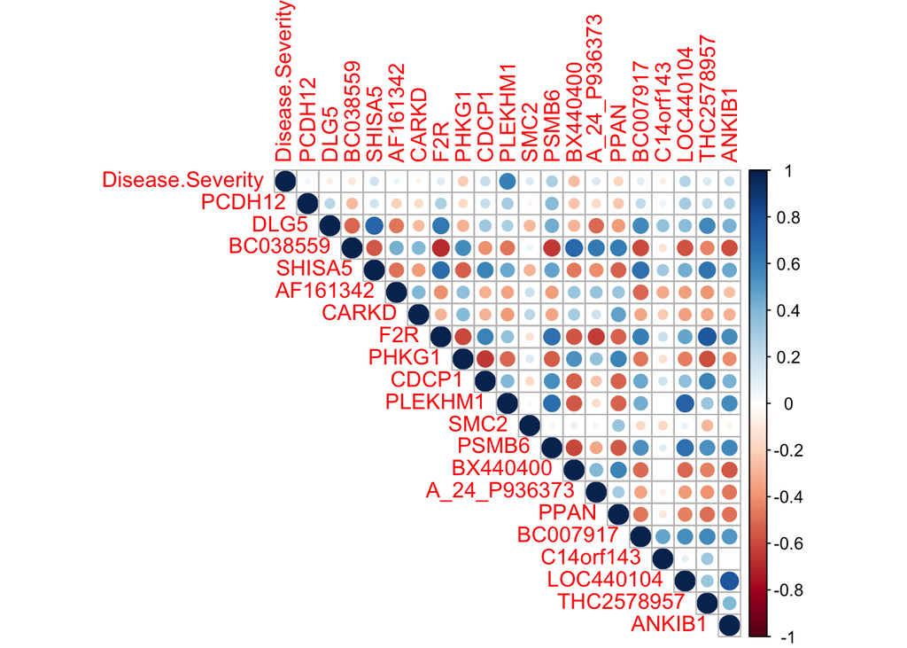

```r
M<-cor(fullData)
corrplot(M,type="upper")
```

The correlation plot gives us some idea about which variables might be useful in predicting disease severtiy but we will run our own tests and see if we can find the best model.

### Full Additive Model

```r
full_model = lm(Disease.Severity~.,data = fullData)
summary(full_model)
```

```
##
## Call:
## lm(formula = Disease.Severity ~ ., data = fullData)
##
## Residuals:
##     Min      1Q  Median      3Q     Max
## -2.3069 -0.7844 -0.1422  0.5988 12.8654
##
## Coefficients:
##               Estimate Std. Error t value Pr(>|t|)
## (Intercept)  -3.403259   0.883576  -3.852 0.000147 ***
## PCDH12       -0.112777   0.076233  -1.479 0.140209
## DLG5         -0.743025   0.227193  -3.270 0.001214 **
## BC038559     -0.298175   0.367246  -0.812 0.417555
## SHISA5        0.292498   0.323874   0.903 0.367269
## AF161342      0.568462   0.149707   3.797 0.000181 ***
## CARKD         0.173380   0.097949   1.770 0.077842 .
## F2R           1.587816   0.470229   3.377 0.000842 ***
## PHKG1         0.500789   0.237720   2.107 0.036075 *
## CDCP1         0.124248   0.180410   0.689 0.491607
## PLEKHM1       4.061004   0.309838  13.107  < 2e-16 ***
## SMC2          0.086447   0.041384   2.089 0.037657 *
## PSMB6        -0.872610   0.354422  -2.462 0.014441 *
## BX440400     -0.005739   0.265745  -0.022 0.982787
## A_24_P936373  0.528840   0.206534   2.561 0.010997 *
## PPAN          0.324097   0.265618   1.220 0.223472
## BC007917     -0.282504   0.307060  -0.920 0.358383
## C14orf143     0.198250   0.112007   1.770 0.077864 .
## LOC440104    -0.868232   0.309428  -2.806 0.005384 **
## THC2578957    0.437893   0.321298   1.363 0.174059
## ANKIB1        0.083391   0.342849   0.243 0.808013
## ---
## Signif. codes:  0 '***' 0.001 '**' 0.01 '*' 0.05 '.' 0.1 ' ' 1
##
## Residual standard error: 1.39 on 269 degrees of freedom
## Multiple R-squared:  0.5611, Adjusted R-squared:  0.5284
## F-statistic: 17.19 on 20 and 269 DF,  p-value: < 2.2e-16
```

```r
#Mean of residuals:
mean(full_model$residuals)
```

```
## [1] -1.442475e-17
```

```r
#Maximum VIF value
(max(vif_vals = vif(full_model)))
```

```
## [1] 5.687746
```

We can see from the above analysis that the model operates at a Multiple R Squared value of 0.5611 and shows that only 9 out of the 20 variables are significant at a 5% significance level.

### Model/Variable Selection

Now we will attempt to eliminate some variables that are not useful to our model.

Backward, forward, and stepwise search are all useful, but do have an obvious issue. By not checking every possible model, sometimes they will miss the best possible model. So we go with using the exhaustive search method. This algorithm compares models at each step by removing and adding variables to find the `best` model.

```r
#Running the exhaustive search algorithm
all_full_mod = summary(regsubsets(Disease.Severity ~ ., data = fullData, nvmax = NULL))
p = length(coef(full_model))
n = length(resid(full_model))
```

Finding and training the model with the most adjusted R Squared value:

```r
best_r2_ind = which.max(all_full_mod$adjr2)
#all_full_mod$which[best_r2_ind, ]
model_R2 = lm(Disease.Severity~PCDH12+DLG5+AF161342+CARKD+F2R+PHKG1+PLEKHM1+SMC2+PSMB6+A_24_P936373+C14orf143+LOC440104+THC2578957, data = fullData)
```

Finding and training the model with the least AIC value:

```r
full_mod_aic = n * log(all_full_mod$rss / n) + 2 * (2:p)
best_aic_ind = which.min(full_mod_aic)
#all_full_mod$which[best_aic_ind,]
model_aic = lm(Disease.Severity~PCDH12+DLG5+AF161342+CARKD+F2R+PHKG1+PLEKHM1+SMC2+PSMB6+A_24_P936373+C14orf143+LOC440104, data = fullData)
```

Finding and training the model with the least BIC value:

```r
#Getting the indices of the model with the minimum BIC value
full_mod_bic = n * log(all_full_mod$rss / n) + log(n) * (2:p)
best_bic_ind = which.min(full_mod_bic)
#all_full_mod$which[best_bic_ind,]
model_bic = lm(Disease.Severity~DLG5+AF161342+F2R+PLEKHM1+SMC2+PSMB6+A_24_P936373+LOC440104, data = fullData)
```

Here , we find 3 models using the exhaustive search algorithm. There 3 models correspond to a model with the most Adjusted R Squared value, least AIC value and the least BIC value respectively.

We can now alculate the LOOCV-RMSE for each of these models and the full model. This will give us the `best` model to use.

```r
calc_loocv_rmse(model_R2)
```

```
## [1] 1.992744
```

```r
calc_loocv_rmse(model_aic)
```

```
## [1] 1.956237
```

```r
calc_loocv_rmse(model_bic)
```

```
## [1] 1.432302
```

```r
calc_loocv_rmse(full_model)
```

```
## [1] 2.12807
```

The LOOCV-RMSE values above are for all 4 models: model with the best R Squared value, model with the best AIC value, model with the best BIC value and the full additive model.

This tells us that the best model to use is the model with the lower BIC value which uses 8 predictor variables which are the following:

```r
all_full_mod$which[best_bic_ind,]
```

```
##  (Intercept)       PCDH12         DLG5     BC038559       SHISA5
##         TRUE        FALSE         TRUE        FALSE        FALSE
##     AF161342        CARKD          F2R        PHKG1        CDCP1
##         TRUE        FALSE         TRUE        FALSE        FALSE
##      PLEKHM1         SMC2        PSMB6     BX440400 A_24_P936373
##         TRUE         TRUE         TRUE        FALSE         TRUE
##         PPAN     BC007917    C14orf143    LOC440104   THC2578957
##        FALSE        FALSE        FALSE         TRUE        FALSE
##       ANKIB1
##        FALSE
```

Thus this is our `best` model.

### Model Diagnosis

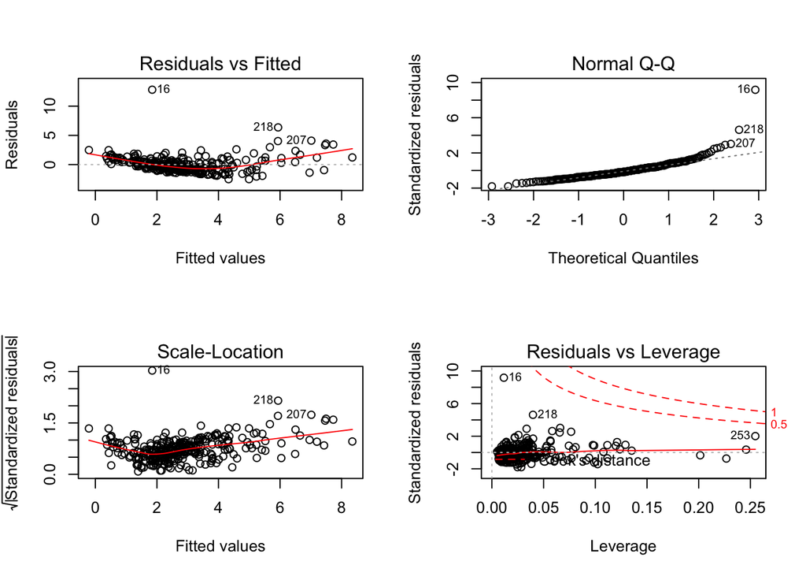

```r
par(mfrow=c(2,2))
plot(model_bic)
```

The Residual vs Fitted Plot shows that the residuals don’t exactly lie equally on both sides of the line, which says that our model may violate the constance variance condition.

Similarly, the Normal Q-Q plot shows that the residuals don’t exactly follow a straight line, violating the constance variance condition.

We can confirm these with the Breusch Pagan test and the Shapiro Wilk test.

```r
shapiro.test(resid(model_bic))
```

```
##
##  Shapiro-Wilk normality test
##
## data:  resid(model_bic)
## W = 0.78975, p-value < 2.2e-16
```

So the small p-value says that the residuals do not follow a normal curve.

```r
bptest(model_bic)
```

```
##
##  studentized Breusch-Pagan test
##
## data:  model_bic
## BP = 3.7041, df = 8, p-value = 0.8828
```

However, it looks like our residuals do have equal variance proved by the large p-value.

We can check if any of the predictor variables are correlated by calculating the VIF values:

```r
vif(model_bic)
```

```
##         DLG5     AF161342          F2R      PLEKHM1         SMC2
##     2.020437     1.412785     3.085876     2.700382     1.170256
##        PSMB6 A_24_P936373    LOC440104
##     3.015283     1.899101     2.717883
```

Since none of the VIF values are greater than 5, none of the predictor variables are correlated to one another and we are good.

We can perform the Box-Cox transformation method to improve our model so it does not violate the assumptions.

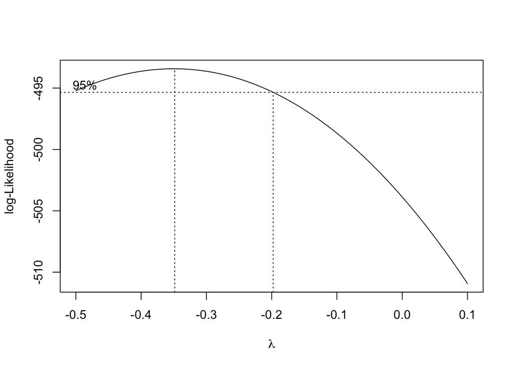

```r
boxcox(model_bic, lambda = seq(-0.5, 0.1, by = 0.05), plotit = TRUE)
```

```r
model_box = lm(((Disease.Severity^-0.29)-1)/(-0.29)~DLG5+AF161342+F2R+PLEKHM1+SMC2+PSMB6+A_24_P936373+LOC440104, data = fullData)

bptest(model_box)
```

```
##
##  studentized Breusch-Pagan test
##
## data:  model_box
## BP = 11.4, df = 8, p-value = 0.1801
```

```r
shapiro.test(model_box$residuals)
```

```
##
##  Shapiro-Wilk normality test
##
## data:  model_box$residuals
## W = 0.97927, p-value = 0.0003248
```

This model gives us a much better value for the Shapiro Wilk Test for normality of errors however it still violates some assumptions, we will see if we can improve our model by handling influential points and outliers.

So we can find the points that are highly influential based on their Cook’s distance which is a heuristic that takes account of both Outliers and High Leverage points:

```r
which(cooks.distance(model_bic) > 4 / length(cooks.distance(model_bic)))
```

```
##  16  49  82  96  98 127 181 207 216 218 245 253 277 290
##  16  49  82  96  98 127 181 207 216 218 245 253 277 290
```

```r
model_box_cooks = cooks.distance(model_box)
model_box2 = lm(((Disease.Severity^-0.29)-1)/(-0.29)~DLG5+AF161342+F2R+PLEKHM1+SMC2+PSMB6+A_24_P936373+LOC440104, data = fullData, subset = model_box_cooks <= 4 / length(model_box_cooks))
```

We can check the assumptions from the Fitted vs Residuals and the Normal Q-Q plots. And confirm the results using the Breusch-Pagan and Shapiro Wilk test as well.

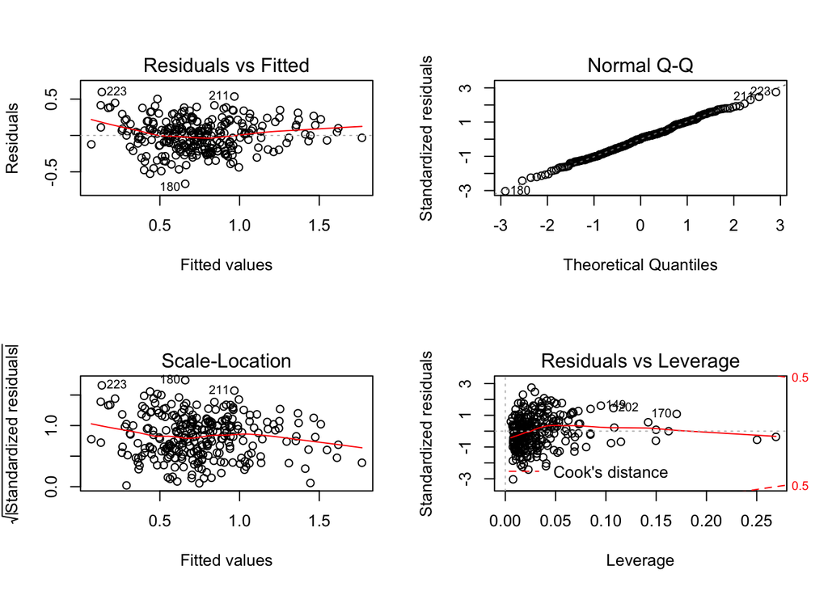

```r
par(mfrow=c(2,2))
plot(model_box2)
```

```r
bptest(model_box2)
```

```
##
##  studentized Breusch-Pagan test
##
## data:  model_box2
## BP = 9.2245, df = 8, p-value = 0.3237
```

```r
shapiro.test(model_box2$residuals)
```

```
##
##  Shapiro-Wilk normality test
##
## data:  model_box2$residuals
## W = 0.9976, p-value = 0.9622
```

```r
mean(model_box2$residuals)
```

```
## [1] -2.767422e-18
```

Now that we have checked our model for the assumptions, we can check if it is indeed better than the other modesls. We can compare the LOOCV-RMSE as we have done before between the untranformed and the transformed model.

```r
calc_loocv_rmse(model_bic)
```

```
## [1] 1.432302
```

```r
calc_loocv_rmse(model_box2)
```

```
## [1] 0.223033
```

We see that there is a huge difference the LOOCV-RMSE of the two models, mainly due to the fact that we have removed the entries that had the highest deviation from the regression line.

This tells us that our `model_box2` model does not violate any assumptions, and so we can stop here. We have transformed our `best` model that had the best LOOCV-RMSE and improved it so it does not violate any assumptions.

This model fits the same predictor variables but to a power of the response variable without points that are highly influential.